# Week 4 | Data Dive — Sampling and Drawing Conclusions

Raghuveer Venkatesh

2024-09-25

# Introduction

In this project, we take five random samples from our existing player data to mimic how we might gather information from a larger group. By looking closely at these samples, we want to spot any differences or unusual findings among them, as well as identify common traits.

## Creating 5 different sub samples from our data and looking at the summary

```r
# Set seed for reproducibility
set.seed(12345)

# Total rows in the data set
n <- nrow(Fifa_Players_Data)

# Loop to create 5 separate data frames for the 5 samples
for (i in 1:5) {
  sample_data <- Fifa_Players_Data[sample(1:n, size = ceiling(0.5 * n), replace = TRUE), ]
  assign(paste0("sample", i), sample_data)  # Dynamically assign to separate data frames
}

# Merging the data sets so we can compare the differences between them

# Create a sub sample_id column in each data frame
sample1$subsample_id <- 1
sample2$subsample_id <- 2
sample3$subsample_id <- 3
sample4$subsample_id <- 4
sample5$subsample_id <- 5

# Combine all samples into one data frame
combined_data <- bind_rows(sample1, sample2, sample3, sample4, sample5)

# Summarize key statistics for each sub sample including categorical columns
summary_stats_continuos <- combined_data |>
  group_by(subsample_id) |>
  summarise(
    avg_overall_rating = mean(overall_rating, na.rm = TRUE),
    avg_potential = mean(potential, na.rm = TRUE),
    avg_strength = mean(strength, na.rm = TRUE),
    avg_age = mean(age, na.rm = TRUE),
    avg_wage = mean(wage_euro, na.rm = TRUE),
    avg_height = mean(height_cm, na.rm = TRUE),
  )

# Summarize key statistics for each sub sample including categorical columns
summary_stats_categorical <- combined_data |>
  group_by(subsample_id) |>
  summarise(
    # Summary for categorical columns
    most_common_position = names(which.max(table(positions))),
    most_common_national_team = names(which.max(table(national_team))),
    most_common_body_type = names(which.max(table(body_type)))
  )

print(summary_stats_continuos)
```

```
## # A tibble: 5 × 7
##   subsample_id avg_overall_rating avg_potential avg_strength avg_age avg_wage
##          <dbl>              <dbl>         <dbl>        <dbl>   <dbl>    <dbl>
## 1            1               66.3          71.5         65.1    25.5    9972.
## 2            2               66.1          71.4         65.2    25.5    9885.
## 3            3               66.3          71.5         65.0    25.5   10088.
## 4            4               66.3          71.4         65.3    25.7    9750.
## 5            5               66.2          71.4         65.2    25.5    9697.
## # ℹ 1 more variable: avg_height <dbl>
```

```r
print(summary_stats_categorical)
```

```
## # A tibble: 5 × 4
##   subsample_id most_common_position most_common_national…¹ most_common_body_type
##          <dbl> <chr>                <chr>                  <chr>
## 1            1 CB                   Czech Republic         Normal
## 2            2 CB                   Scotland               Normal
## 3            3 CB                   England                Normal
## 4            4 CB                   Poland                 Normal
## 5            5 CB                   Poland                 Normal
## # ℹ abbreviated name: ¹most_common_national_team
```

## Summary and observations for categorical data

Most common body type across the data samples are “Normal”. The national teams which have a significantly higher presence include the Czech Republic, Scotland, England. Poland appearing twice, indicating a strong presence of Polish players samples 4 and 5.

# Visualising to identify key differences in the samples.

## Visualising overall rating and potential

### Rating

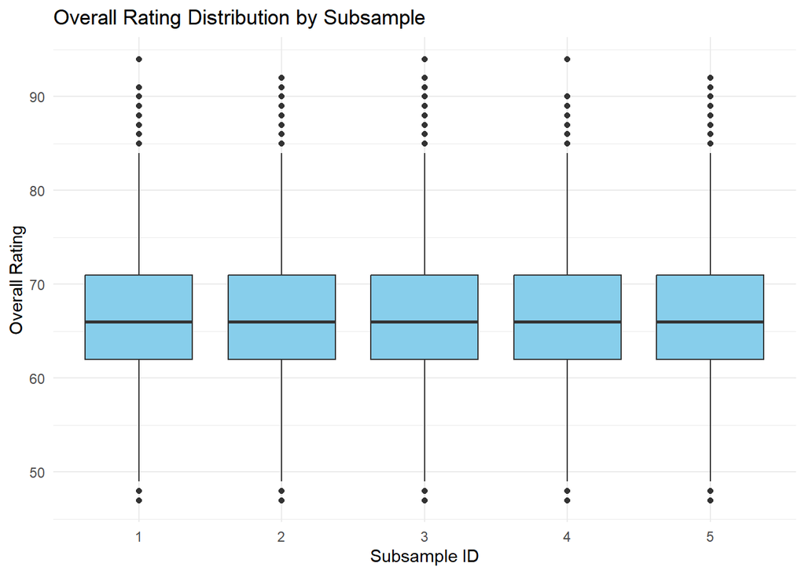

```r
# Visualizations to understand if there are any key differences in the data
ggplot(combined_data, aes(x = factor(subsample_id), y = overall_rating)) +
  geom_boxplot(fill = "skyblue") +
  labs(title = "Overall Rating Distribution by Subsample",
       x = "Subsample ID",
       y = "Overall Rating") +
  theme_minimal()
```

### Potential

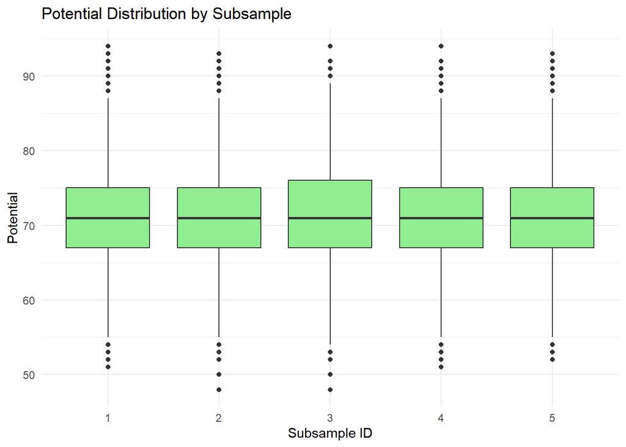

```r
# Box plot for Potential by Sub sample
ggplot(combined_data, aes(x = factor(subsample_id), y = potential)) +
  geom_boxplot(fill = "lightgreen") +
  labs(title = "Potential Distribution by Subsample",
       x = "Subsample ID",
       y = "Potential") +
  theme_minimal()
```

## Visualising wage and value

### Wage

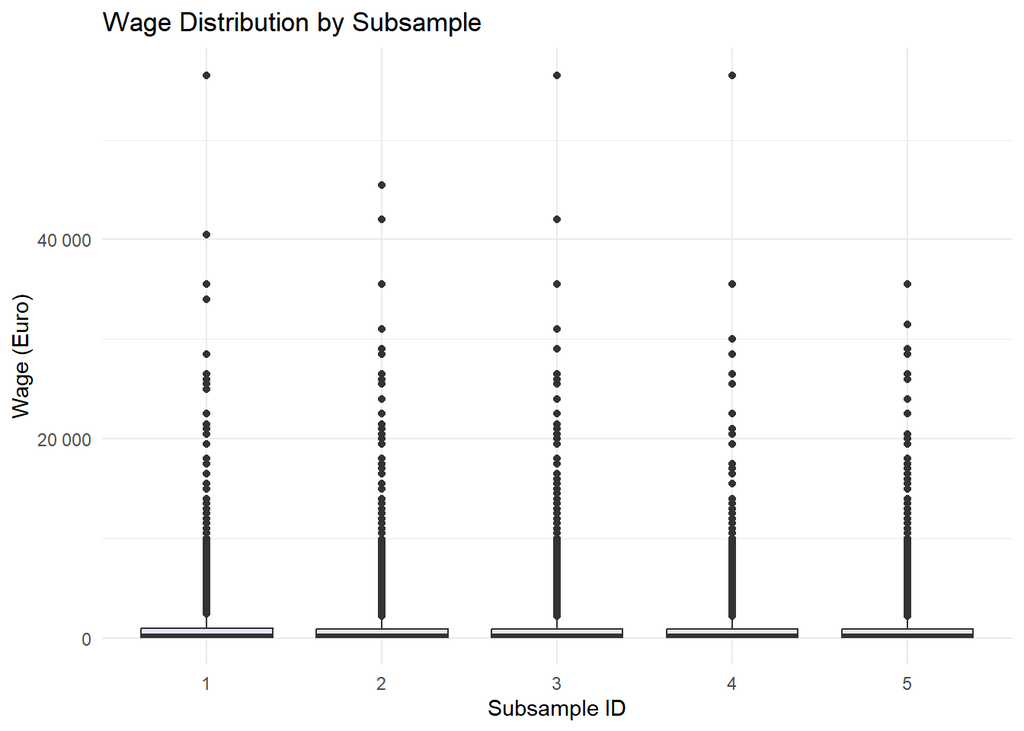

```r
# Box plot for Wage in Euro by Sub sample
ggplot(combined_data, aes(x = factor(subsample_id), y = wage_euro)) +
  geom_boxplot(fill = "lavender") +
  labs(title = "Wage Distribution by Subsample",
       x = "Subsample ID",
       y = "Wage (Euro)") +
  scale_y_continuous(labels = label_number(scale = 1e-1)) +
  theme_minimal()
```

### Value

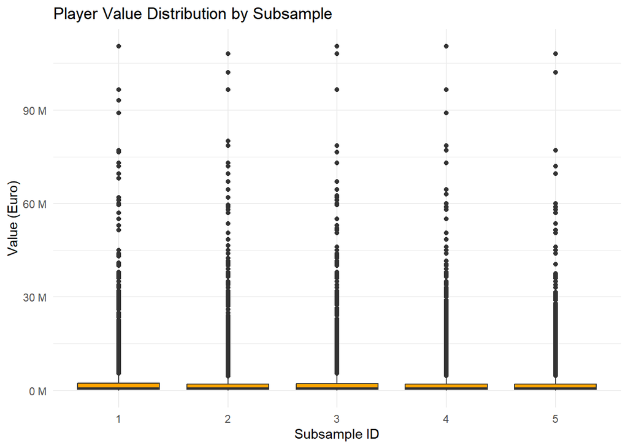

```r
# Box plot for Value in Euro by Sub sample
ggplot(combined_data, aes(x = factor(subsample_id), y = value_euro)) +
  geom_boxplot(fill = "orange") +
  labs(title = "Player Value Distribution by Subsample",
       x = "Subsample ID",
       y = "Value (Euro)") +
  scale_y_continuous(labels = label_number(scale = 1e-6, suffix = " M")) +
  theme_minimal()
```

### How different are the wages and value and any anomalies?

Samples 1, 3, and 4 include players with the highest wages and market values, indicating an anomaly compared to samples 2 and 5. The difference is wages might also indicate a difference in the concentration of players from different markets.

## Visualising Age and Height

### Age

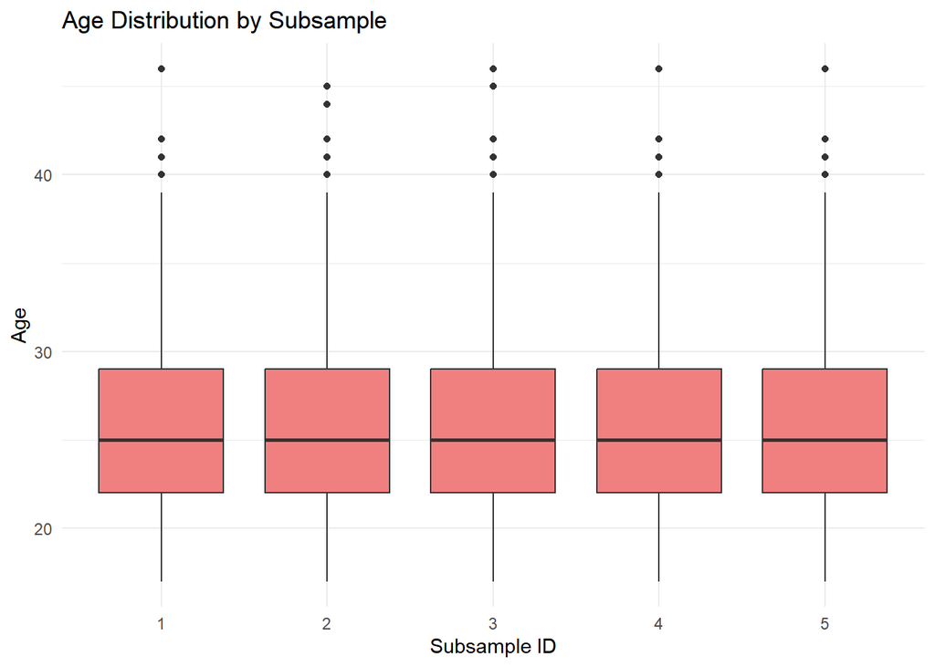

```r
# Box plot for Age by Subsample
ggplot(combined_data, aes(x = factor(subsample_id), y = age)) +
  geom_boxplot(fill = "lightcoral") +
  labs(title = "Age Distribution by Subsample",
       x = "Subsample ID",
       y = "Age") +
  theme_minimal()
```

### How different are the ages amongst the samples ?

The ages remain relatively stable across all the samples with very few differences.

### Height

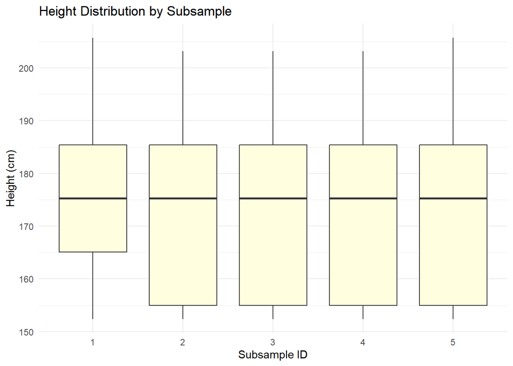

```r
# Box plot for Height by Sub sample
ggplot(combined_data, aes(x = factor(subsample_id), y = height_cm)) +
  geom_boxplot(fill = "lightyellow") +
  labs(title = "Height Distribution by Subsample",
       x = "Subsample ID",
       y = "Height (cm)") +
  theme_minimal()
```

## MONTE - CARLO Simulations

### Monte Carlo simulations are a way to understand uncertainty by running many repeated random samples from a dataset. By simulating different scenarios, we can see how results might change and get a better idea of what to expect in real-life situations. This helps us make more informed decisions based on a range of possible outcomes.

### Taking 1000 samples

```r
# Set seed for reproducibility
set.seed(12345)

# Number of simulations
n_simulations <- 1000

# Create an empty list to store results
simulation_results <- vector("list", n_simulations)

# Run Monte Carlo Simulation
for (i in 1:n_simulations) {

  # Sample with replacement from the data set
  sampled_data <- Fifa_Players_Data |>
    sample_frac(size = 0.5, replace = TRUE) # Use 50% size of the data

  # Calculate key statistics
  stats <- sampled_data |>
    summarise(
      avg_overall_rating = mean(overall_rating, na.rm = TRUE),
      avg_potential = mean(potential, na.rm = TRUE),
      avg_value_euro = mean(value_euro, na.rm = TRUE),
      avg_age = mean(age, na.rm = TRUE)
    )

  # Store the results
  simulation_results[[i]] <- stats
}

# Combine all results into a single dataframe
simulation_results_df <- do.call(rbind, simulation_results)

# View summary of simulation results
summary(simulation_results_df)
```

```
##  avg_overall_rating avg_potential   avg_value_euro       avg_age
##  Min.   :66.01      Min.   :71.27   Min.   :2286023   Min.   :25.38
##  1st Qu.:66.19      1st Qu.:71.38   1st Qu.:2439135   1st Qu.:25.53
##  Median :66.24      Median :71.43   Median :2475996   Median :25.57
##  Mean   :66.24      Mean   :71.43   Mean   :2477560   Mean   :25.57
##  3rd Qu.:66.29      3rd Qu.:71.47   3rd Qu.:2517947   3rd Qu.:25.60
##  Max.   :66.52      Max.   :71.65   Max.   :2663477   Max.   :25.74
```

### Taking 3000 samples

```r
# Set seed for reproducibility
set.seed(12345)

# Number of simulations
n_simulations <- 3000

# Create an empty list to store results
simulation_results <- vector("list", n_simulations)

# Run Monte Carlo Simulation
for (i in 1:n_simulations) {

  # Sample with replacement from the data set
  sampled_data <- Fifa_Players_Data |>
    sample_frac(size = 0.5, replace = TRUE) # Use 50% size of the data

  # Calculate key statistics
  stats <- sampled_data |>
    summarise(
      avg_overall_rating = mean(overall_rating, na.rm = TRUE),
      avg_potential = mean(potential, na.rm = TRUE),
      avg_value_euro = mean(value_euro, na.rm = TRUE),
      avg_age = mean(age, na.rm = TRUE)
    )

  # Store the results
  simulation_results[[i]] <- stats
}

# Combine all results into a single dataframe
simulation_results_df <- do.call(rbind, simulation_results)

# View summary of simulation results
summary(simulation_results_df)
```

```
##  avg_overall_rating avg_potential   avg_value_euro       avg_age
##  Min.   :65.98      Min.   :71.21   Min.   :2286023   Min.   :25.38
##  1st Qu.:66.19      1st Qu.:71.39   1st Qu.:2440310   1st Qu.:25.53
##  Median :66.24      Median :71.43   Median :2478967   Median :25.56
##  Mean   :66.24      Mean   :71.43   Mean   :2479733   Mean   :25.57
##  3rd Qu.:66.29      3rd Qu.:71.47   3rd Qu.:2521244   3rd Qu.:25.60
##  Max.   :66.52      Max.   :71.65   Max.   :2693747   Max.   :25.76
```

### Observations from the Monte-Carlo simulations of Overall rating and Value in Euro

1. For the Average overall rating, the narrow spread (IQR: 66.19 to 66.29) indicates that the overall rating of the players remains fairly consistent across the different simulations.
2. For the Average value in Euro the interquartile range (2,439,135 to 2,517,947 euros) shows that player value varies more than the rating. This larger variability could be due to the influence of different factors like age, potential etc…,
3. There is a slight increase in the 3rd quartile and maximum values for avg_value_euro when moving from 1000 to 3000 samples, suggesting that a larger sample size might capture more extreme values.

## Overall Conclusion for the investigation

Because we have chosen a FIFA data set where the primary population is Football players from Europe, the values across the different categories remain relatively stable especially the physical attributes because they are chosen from a particular demographic.

## How this investigation affects how I draw conclusions to data in the future.

In future data analysis, it’s important to use different random samples to capture variability and recognize any outliers that could skew results. We should also consider the context, like player backgrounds or market conditions, to avoid drawing misleading conclusions. Using methods like Monte Carlo simulations can help us understand uncertainty and make sure our findings are reliable.